# Optimal Treatment Analysis

## Outcome Variable

**Outcome Variable:** ever_wasted

## Predictor Variables

**Intervention Variable:** mwtkg

**Adjustment Set:**

- arm
- W_mage
- meducyrs
- feducyrs
- single
- brthmon
- W_parity
- delta_W_mage
- delta_meducyrs
- delta_feducyrs
- delta_single
- delta_brthmon
- delta_W_parity

## Stratifying Variables

The analysis was stratified on these variable(s):

- agecat
- studyid
- country

## Data Summary

| agecat | studyid | country | mwtkg | ever_wasted | n_cell | n |
| --- | --- | --- | --- | --- | --- | --- |
| 0-24 months | ki0047075b-MAL-ED | BANGLADESH | >=58 kg | 0 | 39 | 254 |
| 0-24 months | ki0047075b-MAL-ED | BANGLADESH | >=58 kg | 1 | 9 | 254 |
| 0-24 months | ki0047075b-MAL-ED | BANGLADESH | <52 kg | 0 | 97 | 254 |
| 0-24 months | ki0047075b-MAL-ED | BANGLADESH | <52 kg | 1 | 65 | 254 |
| 0-24 months | ki0047075b-MAL-ED | BANGLADESH | [52-58) kg | 0 | 33 | 254 |
| 0-24 months | ki0047075b-MAL-ED | BANGLADESH | [52-58) kg | 1 | 11 | 254 |
| 0-24 months | ki0047075b-MAL-ED | BRAZIL | >=58 kg | 0 | 132 | 221 |
| 0-24 months | ki0047075b-MAL-ED | BRAZIL | >=58 kg | 1 | 11 | 221 |
| 0-24 months | ki0047075b-MAL-ED | BRAZIL | <52 kg | 0 | 40 | 221 |
| 0-24 months | ki0047075b-MAL-ED | BRAZIL | <52 kg | 1 | 2 | 221 |
| 0-24 months | ki0047075b-MAL-ED | BRAZIL | [52-58) kg | 0 | 30 | 221 |
| 0-24 months | ki0047075b-MAL-ED | BRAZIL | [52-58) kg | 1 | 6 | 221 |
| 0-24 months | ki0047075b-MAL-ED | INDIA | >=58 kg | 0 | 33 | 242 |
| 0-24 months | ki0047075b-MAL-ED | INDIA | >=58 kg | 1 | 9 | 242 |
| 0-24 months | ki0047075b-MAL-ED | INDIA | <52 kg | 0 | 66 | 242 |
| 0-24 months | ki0047075b-MAL-ED | INDIA | <52 kg | 1 | 84 | 242 |
| 0-24 months | ki0047075b-MAL-ED | INDIA | [52-58) kg | 0 | 28 | 242 |
| 0-24 months | ki0047075b-MAL-ED | INDIA | [52-58) kg | 1 | 22 | 242 |
| 0-24 months | ki0047075b-MAL-ED | NEPAL | >=58 kg | 0 | 67 | 238 |
| 0-24 months | ki0047075b-MAL-ED | NEPAL | >=58 kg | 1 | 13 | 238 |
| 0-24 months | ki0047075b-MAL-ED | NEPAL | <52 kg | 0 | 39 | 238 |
| 0-24 months | ki0047075b-MAL-ED | NEPAL | <52 kg | 1 | 37 | 238 |
| 0-24 months | ki0047075b-MAL-ED | NEPAL | [52-58) kg | 0 | 63 | 238 |
| 0-24 months | ki0047075b-MAL-ED | NEPAL | [52-58) kg | 1 | 19 | 238 |
| 0-24 months | ki0047075b-MAL-ED | PERU | >=58 kg | 0 | 96 | 290 |
| 0-24 months | ki0047075b-MAL-ED | PERU | >=58 kg | 1 | 8 | 290 |
| 0-24 months | ki0047075b-MAL-ED | PERU | <52 kg | 0 | 102 | 290 |
| 0-24 months | ki0047075b-MAL-ED | PERU | <52 kg | 1 | 13 | 290 |
| 0-24 months | ki0047075b-MAL-ED | PERU | [52-58) kg | 0 | 66 | 290 |
| 0-24 months | ki0047075b-MAL-ED | PERU | [52-58) kg | 1 | 5 | 290 |

[output cut: 252 more lines]

The following strata were considered:

- agecat: 0-24 months, studyid: ki0047075b-MAL-ED, country: BANGLADESH
- agecat: 0-24 months, studyid: ki0047075b-MAL-ED, country: BRAZIL
- agecat: 0-24 months, studyid: ki0047075b-MAL-ED, country: INDIA
- agecat: 0-24 months, studyid: ki0047075b-MAL-ED, country: NEPAL
- agecat: 0-24 months, studyid: ki0047075b-MAL-ED, country: PERU
- agecat: 0-24 months, studyid: ki0047075b-MAL-ED, country: SOUTH AFRICA
- agecat: 0-24 months, studyid: ki0047075b-MAL-ED, country: TANZANIA, UNITED REPUBLIC OF
- agecat: 0-24 months, studyid: ki1000304b-SAS-CompFeed, country: INDIA
- agecat: 0-24 months, studyid: ki1017093-NIH-Birth, country: BANGLADESH
- agecat: 0-24 months, studyid: ki1017093b-PROVIDE, country: BANGLADESH
- agecat: 0-24 months, studyid: ki1017093c-NIH-Crypto, country: BANGLADESH
- agecat: 0-24 months, studyid: ki1066203-TanzaniaChild2, country: TANZANIA, UNITED REPUBLIC OF
- agecat: 0-24 months, studyid: ki1112895-iLiNS-Zinc, country: BURKINA FASO
- agecat: 0-24 months, studyid: ki1119695-PROBIT, country: BELARUS
- agecat: 0-24 months, studyid: ki1126311-ZVITAMBO, country: ZIMBABWE
- agecat: 0-24 months, studyid: ki1148112-LCNI-5, country: MALAWI
- agecat: 0-6 months, studyid: ki0047075b-MAL-ED, country: BANGLADESH
- agecat: 0-6 months, studyid: ki0047075b-MAL-ED, country: BRAZIL
- agecat: 0-6 months, studyid: ki0047075b-MAL-ED, country: INDIA
- agecat: 0-6 months, studyid: ki0047075b-MAL-ED, country: NEPAL
- agecat: 0-6 months, studyid: ki0047075b-MAL-ED, country: PERU
- agecat: 0-6 months, studyid: ki0047075b-MAL-ED, country: SOUTH AFRICA
- agecat: 0-6 months, studyid: ki0047075b-MAL-ED, country: TANZANIA, UNITED REPUBLIC OF
- agecat: 0-6 months, studyid: ki1000304b-SAS-CompFeed, country: INDIA
- agecat: 0-6 months, studyid: ki1017093-NIH-Birth, country: BANGLADESH
- agecat: 0-6 months, studyid: ki1017093b-PROVIDE, country: BANGLADESH
- agecat: 0-6 months, studyid: ki1017093c-NIH-Crypto, country: BANGLADESH
- agecat: 0-6 months, studyid: ki1066203-TanzaniaChild2, country: TANZANIA, UNITED REPUBLIC OF
- agecat: 0-6 months, studyid: ki1119695-PROBIT, country: BELARUS
- agecat: 0-6 months, studyid: ki1126311-ZVITAMBO, country: ZIMBABWE
- agecat: 0-6 months, studyid: ki1148112-LCNI-5, country: MALAWI
- agecat: 6-24 months, studyid: ki0047075b-MAL-ED, country: BANGLADESH
- agecat: 6-24 months, studyid: ki0047075b-MAL-ED, country: BRAZIL
- agecat: 6-24 months, studyid: ki0047075b-MAL-ED, country: INDIA
- agecat: 6-24 months, studyid: ki0047075b-MAL-ED, country: NEPAL
- agecat: 6-24 months, studyid: ki0047075b-MAL-ED, country: PERU
- agecat: 6-24 months, studyid: ki0047075b-MAL-ED, country: SOUTH AFRICA
- agecat: 6-24 months, studyid: ki0047075b-MAL-ED, country: TANZANIA, UNITED REPUBLIC OF
- agecat: 6-24 months, studyid: ki1000304b-SAS-CompFeed, country: INDIA
- agecat: 6-24 months, studyid: ki1017093-NIH-Birth, country: BANGLADESH
- agecat: 6-24 months, studyid: ki1017093b-PROVIDE, country: BANGLADESH
- agecat: 6-24 months, studyid: ki1017093c-NIH-Crypto, country: BANGLADESH
- agecat: 6-24 months, studyid: ki1066203-TanzaniaChild2, country: TANZANIA, UNITED REPUBLIC OF
- agecat: 6-24 months, studyid: ki1112895-iLiNS-Zinc, country: BURKINA FASO
- agecat: 6-24 months, studyid: ki1119695-PROBIT, country: BELARUS
- agecat: 6-24 months, studyid: ki1126311-ZVITAMBO, country: ZIMBABWE
- agecat: 6-24 months, studyid: ki1148112-LCNI-5, country: MALAWI

### Dropped Strata

Some strata were dropped due to rare outcomes:

- agecat: 0-24 months, studyid: ki0047075b-MAL-ED, country: BRAZIL
- agecat: 0-6 months, studyid: ki0047075b-MAL-ED, country: BRAZIL
- agecat: 0-6 months, studyid: ki0047075b-MAL-ED, country: PERU
- agecat: 0-6 months, studyid: ki0047075b-MAL-ED, country: SOUTH AFRICA
- agecat: 0-6 months, studyid: ki0047075b-MAL-ED, country: TANZANIA, UNITED REPUBLIC OF
- agecat: 0-6 months, studyid: ki1148112-LCNI-5, country: MALAWI
- agecat: 6-24 months, studyid: ki0047075b-MAL-ED, country: BANGLADESH
- agecat: 6-24 months, studyid: ki0047075b-MAL-ED, country: BRAZIL
- agecat: 6-24 months, studyid: ki0047075b-MAL-ED, country: INDIA
- agecat: 6-24 months, studyid: ki0047075b-MAL-ED, country: PERU
- agecat: 6-24 months, studyid: ki0047075b-MAL-ED, country: SOUTH AFRICA
- agecat: 6-24 months, studyid: ki0047075b-MAL-ED, country: TANZANIA, UNITED REPUBLIC OF
- agecat: 6-24 months, studyid: ki1119695-PROBIT, country: BELARUS

## Methods Detail

We’re interested in the causal parameters $E[Y_a]$ for all values of $a \in \mathcal{A}$. These parameters represent the mean outcome if, possibly contrary to fact, we intervened to set all units to have $A=a$. Under the randomization and positivity assumptions, these are identified by the statistical parameters $\psi_a=E_W[E_{Y|A,W}(Y|A=a,W)]$. In addition, we’re interested in the mean of $Y$, $E[Y]$ under no intervention (the observed mean). We will estimate these parameters by using SuperLearner to fit the relevant likelihood factors – $E_{Y|A,W}(Y|A=a,W)$ and $p(A=a|W)$, and then updating our likelihood fit using a joint TMLE.

For unadjusted analyses ($W=\{\}$), initial likelihoods were estimated using Lrnr_glm to estimate the simple $E(Y|A)$ and Lrnr_mean to estimate $p(A)$. For adjusted analyses, a small library containing Lrnr_glmnet, Lrnr_xgboost, and Lrnr_mean was used.

Having estimated these parameters, we will then use the delta method to estimate relative risks and attributable risks relative to a prespecified baseline level of $A$.

# Results Detail

## Results Plots

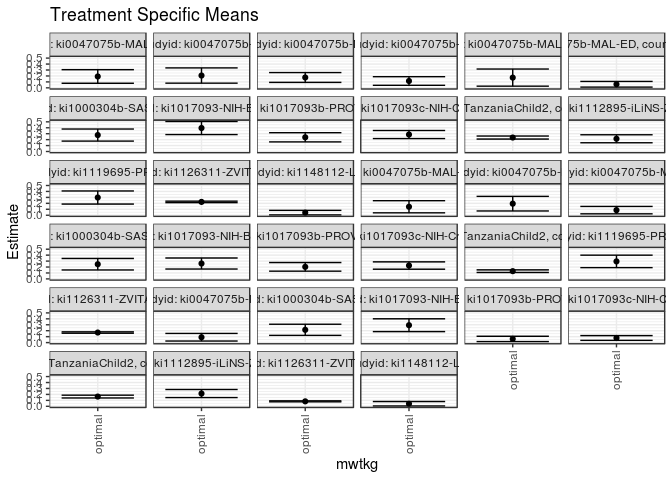

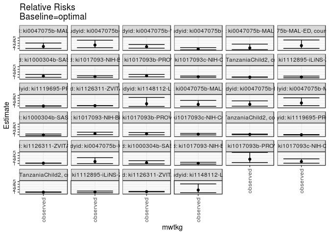

## Results Table

### Parameter: TSM

| agecat | studyid | country | intervention_level | baseline_level | estimate | ci_lower | ci_upper |
| --- | --- | --- | --- | --- | --- | --- | --- |
| 0-24 months | ki0047075b-MAL-ED | BANGLADESH | optimal | NA | 0.1910750 | 0.0765873 | 0.3055627 |
| 0-24 months | ki0047075b-MAL-ED | INDIA | optimal | NA | 0.2069689 | 0.0787133 | 0.3352245 |
| 0-24 months | ki0047075b-MAL-ED | NEPAL | optimal | NA | 0.1742081 | 0.0912629 | 0.2571533 |
| 0-24 months | ki0047075b-MAL-ED | PERU | optimal | NA | 0.1151388 | 0.0428480 | 0.1874297 |
| 0-24 months | ki0047075b-MAL-ED | SOUTH AFRICA | optimal | NA | 0.1718372 | 0.0275651 | 0.3161093 |
| 0-24 months | ki0047075b-MAL-ED | TANZANIA, UNITED REPUBLIC OF | optimal | NA | 0.0600296 | 0.0123968 | 0.1076624 |
| 0-24 months | ki1000304b-SAS-CompFeed | INDIA | optimal | NA | 0.2770441 | 0.1757300 | 0.3783582 |
| 0-24 months | ki1017093-NIH-Birth | BANGLADESH | optimal | NA | 0.3954118 | 0.2852070 | 0.5056166 |
| 0-24 months | ki1017093b-PROVIDE | BANGLADESH | optimal | NA | 0.2393318 | 0.1619294 | 0.3167342 |
| 0-24 months | ki1017093c-NIH-Crypto | BANGLADESH | optimal | NA | 0.2858166 | 0.2178163 | 0.3538168 |
| 0-24 months | ki1066203-TanzaniaChild2 | TANZANIA, UNITED REPUBLIC OF | optimal | NA | 0.2352462 | 0.2095419 | 0.2609505 |
| 0-24 months | ki1112895-iLiNS-Zinc | BURKINA FASO | optimal | NA | 0.2146724 | 0.1469942 | 0.2823506 |
| 0-24 months | ki1119695-PROBIT | BELARUS | optimal | NA | 0.2978427 | 0.1877615 | 0.4079240 |
| 0-24 months | ki1126311-ZVITAMBO | ZIMBABWE | optimal | NA | 0.2239443 | 0.2117745 | 0.2361141 |
| 0-24 months | ki1148112-LCNI-5 | MALAWI | optimal | NA | 0.0432258 | 0.0052514 | 0.0812001 |
| 0-6 months | ki0047075b-MAL-ED | BANGLADESH | optimal | NA | 0.1420781 | 0.0400839 | 0.2440724 |
| 0-6 months | ki0047075b-MAL-ED | INDIA | optimal | NA | 0.1944466 | 0.0713698 | 0.3175235 |
| 0-6 months | ki0047075b-MAL-ED | NEPAL | optimal | NA | 0.0854216 | 0.0232978 | 0.1475454 |
| 0-6 months | ki1000304b-SAS-CompFeed | INDIA | optimal | NA | 0.2471813 | 0.1505007 | 0.3438618 |
| 0-6 months | ki1017093-NIH-Birth | BANGLADESH | optimal | NA | 0.2591537 | 0.1664119 | 0.3518956 |
| 0-6 months | ki1017093b-PROVIDE | BANGLADESH | optimal | NA | 0.2028383 | 0.1299858 | 0.2756909 |
| 0-6 months | ki1017093c-NIH-Crypto | BANGLADESH | optimal | NA | 0.2250371 | 0.1634381 | 0.2866361 |
| 0-6 months | ki1066203-TanzaniaChild2 | TANZANIA, UNITED REPUBLIC OF | optimal | NA | 0.1303409 | 0.1085207 | 0.1521610 |
| 0-6 months | ki1119695-PROBIT | BELARUS | optimal | NA | 0.2945574 | 0.1898331 | 0.3992818 |
| 0-6 months | ki1126311-ZVITAMBO | ZIMBABWE | optimal | NA | 0.1693503 | 0.1579490 | 0.1807517 |
| 6-24 months | ki0047075b-MAL-ED | NEPAL | optimal | NA | 0.0901934 | 0.0260815 | 0.1543054 |
| 6-24 months | ki1000304b-SAS-CompFeed | INDIA | optimal | NA | 0.2152649 | 0.1214489 | 0.3090809 |
| 6-24 months | ki1017093-NIH-Birth | BANGLADESH | optimal | NA | 0.2928283 | 0.1851787 | 0.4004779 |
| 6-24 months | ki1017093b-PROVIDE | BANGLADESH | optimal | NA | 0.0620471 | 0.0174150 | 0.1066793 |
| 6-24 months | ki1017093c-NIH-Crypto | BANGLADESH | optimal | NA | 0.0776780 | 0.0375545 | 0.1178016 |
| 6-24 months | ki1066203-TanzaniaChild2 | TANZANIA, UNITED REPUBLIC OF | optimal | NA | 0.1635940 | 0.1398834 | 0.1873047 |
| 6-24 months | ki1112895-iLiNS-Zinc | BURKINA FASO | optimal | NA | 0.2146724 | 0.1469942 | 0.2823506 |
| 6-24 months | ki1126311-ZVITAMBO | ZIMBABWE | optimal | NA | 0.0831499 | 0.0746489 | 0.0916509 |
| 6-24 months | ki1148112-LCNI-5 | MALAWI | optimal | NA | 0.0426802 | 0.0053516 | 0.0800088 |

### Parameter: E(Y)

| agecat | studyid | country | intervention_level | baseline_level | estimate | ci_lower | ci_upper |
| --- | --- | --- | --- | --- | --- | --- | --- |
| 0-24 months | ki0047075b-MAL-ED | BANGLADESH | observed | NA | 0.3346457 | 0.2765014 | 0.3927899 |
| 0-24 months | ki0047075b-MAL-ED | INDIA | observed | NA | 0.4752066 | 0.4121581 | 0.5382551 |
| 0-24 months | ki0047075b-MAL-ED | NEPAL | observed | NA | 0.2899160 | 0.2321510 | 0.3476810 |
| 0-24 months | ki0047075b-MAL-ED | PERU | observed | NA | 0.0896552 | 0.0567177 | 0.1225926 |
| 0-24 months | ki0047075b-MAL-ED | SOUTH AFRICA | observed | NA | 0.2037037 | 0.1555745 | 0.2518329 |
| 0-24 months | ki0047075b-MAL-ED | TANZANIA, UNITED REPUBLIC OF | observed | NA | 0.1250000 | 0.0844083 | 0.1655917 |
| 0-24 months | ki1000304b-SAS-CompFeed | INDIA | observed | NA | 0.3847826 | 0.3023315 | 0.4672337 |
| 0-24 months | ki1017093-NIH-Birth | BANGLADESH | observed | NA | 0.4775641 | 0.4383415 | 0.5167867 |
| 0-24 months | ki1017093b-PROVIDE | BANGLADESH | observed | NA | 0.3602392 | 0.3238339 | 0.3966444 |
| 0-24 months | ki1017093c-NIH-Crypto | BANGLADESH | observed | NA | 0.3311258 | 0.2975342 | 0.3647175 |
| 0-24 months | ki1066203-TanzaniaChild2 | TANZANIA, UNITED REPUBLIC OF | observed | NA | 0.2372449 | 0.2200495 | 0.2544403 |
| 0-24 months | ki1112895-iLiNS-Zinc | BURKINA FASO | observed | NA | 0.2259307 | 0.1907517 | 0.2611097 |
| 0-24 months | ki1119695-PROBIT | BELARUS | observed | NA | 0.2874385 | 0.1857322 | 0.3891448 |
| 0-24 months | ki1126311-ZVITAMBO | ZIMBABWE | observed | NA | 0.2438216 | 0.2358577 | 0.2517856 |
| 0-24 months | ki1148112-LCNI-5 | MALAWI | observed | NA | 0.0787590 | 0.0605107 | 0.0970072 |
| 0-6 months | ki0047075b-MAL-ED | BANGLADESH | observed | NA | 0.2244094 | 0.1730022 | 0.2758167 |
| 0-6 months | ki0047075b-MAL-ED | INDIA | observed | NA | 0.3140496 | 0.2554513 | 0.3726479 |
| 0-6 months | ki0047075b-MAL-ED | NEPAL | observed | NA | 0.1806723 | 0.1316889 | 0.2296556 |
| 0-6 months | ki1000304b-SAS-CompFeed | INDIA | observed | NA | 0.2222222 | 0.1648972 | 0.2795472 |
| 0-6 months | ki1017093-NIH-Birth | BANGLADESH | observed | NA | 0.3569132 | 0.3192325 | 0.3945938 |
| 0-6 months | ki1017093b-PROVIDE | BANGLADESH | observed | NA | 0.2630792 | 0.2296894 | 0.2964690 |
| 0-6 months | ki1017093c-NIH-Crypto | BANGLADESH | observed | NA | 0.2582781 | 0.2270370 | 0.2895193 |
| 0-6 months | ki1066203-TanzaniaChild2 | TANZANIA, UNITED REPUBLIC OF | observed | NA | 0.1403061 | 0.1262673 | 0.1543450 |
| 0-6 months | ki1119695-PROBIT | BELARUS | observed | NA | 0.2822232 | 0.1798711 | 0.3845754 |
| 0-6 months | ki1126311-ZVITAMBO | ZIMBABWE | observed | NA | 0.1803706 | 0.1732226 | 0.1875186 |
| 6-24 months | ki0047075b-MAL-ED | NEPAL | observed | NA | 0.1531915 | 0.1070438 | 0.1993392 |
| 6-24 months | ki1000304b-SAS-CompFeed | INDIA | observed | NA | 0.2714617 | 0.2176472 | 0.3252763 |
| 6-24 months | ki1017093-NIH-Birth | BANGLADESH | observed | NA | 0.2939002 | 0.2554778 | 0.3323226 |
| 6-24 months | ki1017093b-PROVIDE | BANGLADESH | observed | NA | 0.1612378 | 0.1321259 | 0.1903497 |
| 6-24 months | ki1017093c-NIH-Crypto | BANGLADESH | observed | NA | 0.1315068 | 0.1069744 | 0.1560393 |
| 6-24 months | ki1066203-TanzaniaChild2 | TANZANIA, UNITED REPUBLIC OF | observed | NA | 0.1612740 | 0.1450620 | 0.1774860 |
| 6-24 months | ki1112895-iLiNS-Zinc | BURKINA FASO | observed | NA | 0.2259307 | 0.1907517 | 0.2611097 |
| 6-24 months | ki1126311-ZVITAMBO | ZIMBABWE | observed | NA | 0.0973196 | 0.0914209 | 0.1032182 |
| 6-24 months | ki1148112-LCNI-5 | MALAWI | observed | NA | 0.0764563 | 0.0583018 | 0.0946108 |

### Parameter: RR

| agecat | studyid | country | intervention_level | baseline_level | estimate | ci_lower | ci_upper |
| --- | --- | --- | --- | --- | --- | --- | --- |
| 0-24 months | ki0047075b-MAL-ED | BANGLADESH | observed | optimal | 1.7513840 | 0.9997602 | 3.068082 |
| 0-24 months | ki0047075b-MAL-ED | INDIA | observed | optimal | 2.2960291 | 1.2754688 | 4.133186 |
| 0-24 months | ki0047075b-MAL-ED | NEPAL | observed | optimal | 1.6641930 | 1.0942311 | 2.531036 |
| 0-24 months | ki0047075b-MAL-ED | PERU | observed | optimal | 0.7786702 | 0.4707507 | 1.288001 |
| 0-24 months | ki0047075b-MAL-ED | SOUTH AFRICA | observed | optimal | 1.1854459 | 0.5329692 | 2.636704 |
| 0-24 months | ki0047075b-MAL-ED | TANZANIA, UNITED REPUBLIC OF | observed | optimal | 2.0823055 | 1.0240407 | 4.234203 |
| 0-24 months | ki1000304b-SAS-CompFeed | INDIA | observed | optimal | 1.3888859 | 0.9466630 | 2.037688 |
| 0-24 months | ki1017093-NIH-Birth | BANGLADESH | observed | optimal | 1.2077639 | 0.9299261 | 1.568612 |
| 0-24 months | ki1017093b-PROVIDE | BANGLADESH | observed | optimal | 1.5051872 | 1.1137689 | 2.034164 |
| 0-24 months | ki1017093c-NIH-Crypto | BANGLADESH | observed | optimal | 1.1585257 | 0.9391315 | 1.429174 |
| 0-24 months | ki1066203-TanzaniaChild2 | TANZANIA, UNITED REPUBLIC OF | observed | optimal | 1.0084962 | 0.9293715 | 1.094358 |
| 0-24 months | ki1112895-iLiNS-Zinc | BURKINA FASO | observed | optimal | 1.0524438 | 0.7907132 | 1.400809 |
| 0-24 months | ki1119695-PROBIT | BELARUS | observed | optimal | 0.9650682 | 0.8982131 | 1.036899 |
| 0-24 months | ki1126311-ZVITAMBO | ZIMBABWE | observed | optimal | 1.0887601 | 1.0432993 | 1.136202 |
| 0-24 months | ki1148112-LCNI-5 | MALAWI | observed | optimal | 1.8220373 | 0.7838313 | 4.235376 |
| 0-6 months | ki0047075b-MAL-ED | BANGLADESH | observed | optimal | 1.5794793 | 0.8093706 | 3.082339 |
| 0-6 months | ki0047075b-MAL-ED | INDIA | observed | optimal | 1.6150938 | 0.8920192 | 2.924296 |
| 0-6 months | ki0047075b-MAL-ED | NEPAL | observed | optimal | 2.1150657 | 1.0937115 | 4.090204 |
| 0-6 months | ki1000304b-SAS-CompFeed | INDIA | observed | optimal | 0.8990253 | 0.6510694 | 1.241414 |
| 0-6 months | ki1017093-NIH-Birth | BANGLADESH | observed | optimal | 1.3772256 | 0.9827994 | 1.929947 |
| 0-6 months | ki1017093b-PROVIDE | BANGLADESH | observed | optimal | 1.2969896 | 0.9273083 | 1.814048 |
| 0-6 months | ki1017093c-NIH-Crypto | BANGLADESH | observed | optimal | 1.1477136 | 0.8986760 | 1.465764 |
| 0-6 months | ki1066203-TanzaniaChild2 | TANZANIA, UNITED REPUBLIC OF | observed | optimal | 1.0764554 | 0.9454016 | 1.225676 |
| 0-6 months | ki1119695-PROBIT | BELARUS | observed | optimal | 0.9581263 | 0.8748533 | 1.049326 |
| 0-6 months | ki1126311-ZVITAMBO | ZIMBABWE | observed | optimal | 1.0650739 | 1.0091493 | 1.124098 |
| 6-24 months | ki0047075b-MAL-ED | NEPAL | observed | optimal | 1.6984771 | 0.9021571 | 3.197697 |
| 6-24 months | ki1000304b-SAS-CompFeed | INDIA | observed | optimal | 1.2610590 | 0.7907622 | 2.011059 |
| 6-24 months | ki1017093-NIH-Birth | BANGLADESH | observed | optimal | 1.0036604 | 0.7146293 | 1.409590 |
| 6-24 months | ki1017093b-PROVIDE | BANGLADESH | observed | optimal | 2.5986345 | 1.3027120 | 5.183726 |
| 6-24 months | ki1017093c-NIH-Crypto | BANGLADESH | observed | optimal | 1.6929732 | 1.0516678 | 2.725346 |
| 6-24 months | ki1066203-TanzaniaChild2 | TANZANIA, UNITED REPUBLIC OF | observed | optimal | 0.9858185 | 0.8888807 | 1.093328 |
| 6-24 months | ki1112895-iLiNS-Zinc | BURKINA FASO | observed | optimal | 1.0524438 | 0.7907132 | 1.400809 |
| 6-24 months | ki1126311-ZVITAMBO | ZIMBABWE | observed | optimal | 1.1704115 | 1.0776883 | 1.271113 |
| 6-24 months | ki1148112-LCNI-5 | MALAWI | observed | optimal | 1.7913771 | 0.7749099 | 4.141168 |

### Parameter: PAR

| agecat | studyid | country | intervention_level | baseline_level | estimate | ci_lower | ci_upper |
| --- | --- | --- | --- | --- | --- | --- | --- |
| 0-24 months | ki0047075b-MAL-ED | BANGLADESH | optimal | NA | 0.1435707 | 0.0354025 | 0.2517389 |
| 0-24 months | ki0047075b-MAL-ED | INDIA | optimal | NA | 0.2682377 | 0.1461132 | 0.3903622 |
| 0-24 months | ki0047075b-MAL-ED | NEPAL | optimal | NA | 0.1157078 | 0.0405999 | 0.1908158 |
| 0-24 months | ki0047075b-MAL-ED | PERU | optimal | NA | -0.0254837 | -0.0843287 | 0.0333614 |
| 0-24 months | ki0047075b-MAL-ED | SOUTH AFRICA | optimal | NA | 0.0318665 | -0.1055085 | 0.1692416 |
| 0-24 months | ki0047075b-MAL-ED | TANZANIA, UNITED REPUBLIC OF | optimal | NA | 0.0649704 | 0.0182756 | 0.1116652 |
| 0-24 months | ki1000304b-SAS-CompFeed | INDIA | optimal | NA | 0.1077385 | -0.0087720 | 0.2242490 |
| 0-24 months | ki1017093-NIH-Birth | BANGLADESH | optimal | NA | 0.0821523 | -0.0210293 | 0.1853339 |
| 0-24 months | ki1017093b-PROVIDE | BANGLADESH | optimal | NA | 0.1209074 | 0.0485320 | 0.1932828 |
| 0-24 months | ki1017093c-NIH-Crypto | BANGLADESH | optimal | NA | 0.0453093 | -0.0146323 | 0.1052508 |
| 0-24 months | ki1066203-TanzaniaChild2 | TANZANIA, UNITED REPUBLIC OF | optimal | NA | 0.0019987 | -0.0172230 | 0.0212204 |
| 0-24 months | ki1112895-iLiNS-Zinc | BURKINA FASO | optimal | NA | 0.0112582 | -0.0502791 | 0.0727956 |
| 0-24 months | ki1119695-PROBIT | BELARUS | optimal | NA | -0.0104042 | -0.0325429 | 0.0117345 |
| 0-24 months | ki1126311-ZVITAMBO | ZIMBABWE | optimal | NA | 0.0198773 | 0.0103193 | 0.0294353 |
| 0-24 months | ki1148112-LCNI-5 | MALAWI | optimal | NA | 0.0355332 | -0.0017110 | 0.0727773 |
| 0-6 months | ki0047075b-MAL-ED | BANGLADESH | optimal | NA | 0.0823313 | -0.0135534 | 0.1782161 |
| 0-6 months | ki0047075b-MAL-ED | INDIA | optimal | NA | 0.1196029 | 0.0033619 | 0.2358440 |
| 0-6 months | ki0047075b-MAL-ED | NEPAL | optimal | NA | 0.0952507 | 0.0346351 | 0.1558663 |
| 0-6 months | ki1000304b-SAS-CompFeed | INDIA | optimal | NA | -0.0249590 | -0.1042977 | 0.0543796 |
| 0-6 months | ki1017093-NIH-Birth | BANGLADESH | optimal | NA | 0.0977594 | 0.0101509 | 0.1853680 |
| 0-6 months | ki1017093b-PROVIDE | BANGLADESH | optimal | NA | 0.0602409 | -0.0082139 | 0.1286957 |
| 0-6 months | ki1017093c-NIH-Crypto | BANGLADESH | optimal | NA | 0.0332410 | -0.0219192 | 0.0884013 |
| 0-6 months | ki1066203-TanzaniaChild2 | TANZANIA, UNITED REPUBLIC OF | optimal | NA | 0.0099653 | -0.0069403 | 0.0268708 |
| 0-6 months | ki1119695-PROBIT | BELARUS | optimal | NA | -0.0123342 | -0.0385763 | 0.0139079 |
| 0-6 months | ki1126311-ZVITAMBO | ZIMBABWE | optimal | NA | 0.0110203 | 0.0018811 | 0.0201595 |
| 6-24 months | ki0047075b-MAL-ED | NEPAL | optimal | NA | 0.0629981 | 0.0035355 | 0.1224606 |
| 6-24 months | ki1000304b-SAS-CompFeed | INDIA | optimal | NA | 0.0561968 | -0.0488283 | 0.1612220 |
| 6-24 months | ki1017093-NIH-Birth | BANGLADESH | optimal | NA | 0.0010719 | -0.0983817 | 0.1005254 |
| 6-24 months | ki1017093b-PROVIDE | BANGLADESH | optimal | NA | 0.0991907 | 0.0532849 | 0.1450964 |
| 6-24 months | ki1017093c-NIH-Crypto | BANGLADESH | optimal | NA | 0.0538288 | 0.0157984 | 0.0918592 |
| 6-24 months | ki1066203-TanzaniaChild2 | TANZANIA, UNITED REPUBLIC OF | optimal | NA | -0.0023200 | -0.0192572 | 0.0146172 |
| 6-24 months | ki1112895-iLiNS-Zinc | BURKINA FASO | optimal | NA | 0.0112582 | -0.0502791 | 0.0727956 |
| 6-24 months | ki1126311-ZVITAMBO | ZIMBABWE | optimal | NA | 0.0141697 | 0.0072504 | 0.0210890 |
| 6-24 months | ki1148112-LCNI-5 | MALAWI | optimal | NA | 0.0337761 | -0.0027531 | 0.0703053 |

### Parameter: PAF

| agecat | studyid | country | intervention_level | baseline_level | estimate | ci_lower | ci_upper |
| --- | --- | --- | --- | --- | --- | --- | --- |
| 0-24 months | ki0047075b-MAL-ED | BANGLADESH | optimal | NA | 0.4290230 | -0.0002398 | 0.6740634 |
| 0-24 months | ki0047075b-MAL-ED | INDIA | optimal | NA | 0.5644655 | 0.2159745 | 0.7580559 |
| 0-24 months | ki0047075b-MAL-ED | NEPAL | optimal | NA | 0.3991082 | 0.0861163 | 0.6049049 |
| 0-24 months | ki0047075b-MAL-ED | PERU | optimal | NA | -0.2842407 | -1.1242664 | 0.2236029 |
| 0-24 months | ki0047075b-MAL-ED | SOUTH AFRICA | optimal | NA | 0.1564356 | -0.8762811 | 0.6207386 |
| 0-24 months | ki0047075b-MAL-ED | TANZANIA, UNITED REPUBLIC OF | optimal | NA | 0.5197631 | 0.0234763 | 0.7638280 |
| 0-24 months | ki1000304b-SAS-CompFeed | INDIA | optimal | NA | 0.2799984 | -0.0563421 | 0.5092478 |
| 0-24 months | ki1017093-NIH-Birth | BANGLADESH | optimal | NA | 0.1720236 | -0.0753542 | 0.3624939 |
| 0-24 months | ki1017093b-PROVIDE | BANGLADESH | optimal | NA | 0.3356308 | 0.1021477 | 0.5083975 |
| 0-24 months | ki1017093c-NIH-Crypto | BANGLADESH | optimal | NA | 0.1368340 | -0.0648136 | 0.3002949 |
| 0-24 months | ki1066203-TanzaniaChild2 | TANZANIA, UNITED REPUBLIC OF | optimal | NA | 0.0084247 | -0.0759960 | 0.0862218 |
| 0-24 months | ki1112895-iLiNS-Zinc | BURKINA FASO | optimal | NA | 0.0498305 | -0.2646811 | 0.2861267 |
| 0-24 months | ki1119695-PROBIT | BELARUS | optimal | NA | -0.0361962 | -0.1133215 | 0.0355862 |
| 0-24 months | ki1126311-ZVITAMBO | ZIMBABWE | optimal | NA | 0.0815241 | 0.0415022 | 0.1198748 |
| 0-24 months | ki1148112-LCNI-5 | MALAWI | optimal | NA | 0.4511638 | -0.2757848 | 0.7638934 |
| 0-6 months | ki0047075b-MAL-ED | BANGLADESH | optimal | NA | 0.3668799 | -0.2355279 | 0.6755711 |
| 0-6 months | ki0047075b-MAL-ED | INDIA | optimal | NA | 0.3808409 | -0.1210521 | 0.6580374 |
| 0-6 months | ki0047075b-MAL-ED | NEPAL | optimal | NA | 0.5272014 | 0.0856821 | 0.7555134 |
| 0-6 months | ki1000304b-SAS-CompFeed | INDIA | optimal | NA | -0.1123157 | -0.5359346 | 0.1944668 |
| 0-6 months | ki1017093-NIH-Birth | BANGLADESH | optimal | NA | 0.2739026 | -0.0175017 | 0.4818510 |
| 0-6 months | ki1017093b-PROVIDE | BANGLADESH | optimal | NA | 0.2289838 | -0.0783900 | 0.4487468 |
| 0-6 months | ki1017093c-NIH-Crypto | BANGLADESH | optimal | NA | 0.1287025 | -0.1127481 | 0.3177617 |
| 0-6 months | ki1066203-TanzaniaChild2 | TANZANIA, UNITED REPUBLIC OF | optimal | NA | 0.0710252 | -0.0577516 | 0.1841239 |
| 0-6 months | ki1119695-PROBIT | BELARUS | optimal | NA | -0.0437038 | -0.1430488 | 0.0470070 |
| 0-6 months | ki1126311-ZVITAMBO | ZIMBABWE | optimal | NA | 0.0610980 | 0.0090663 | 0.1103977 |
| 6-24 months | ki0047075b-MAL-ED | NEPAL | optimal | NA | 0.4112373 | -0.1084544 | 0.6872749 |
| 6-24 months | ki1000304b-SAS-CompFeed | INDIA | optimal | NA | 0.2070157 | -0.2646026 | 0.5027496 |
| 6-24 months | ki1017093-NIH-Birth | BANGLADESH | optimal | NA | 0.0036471 | -0.3993268 | 0.2905738 |
| 6-24 months | ki1017093b-PROVIDE | BANGLADESH | optimal | NA | 0.6151825 | 0.2323706 | 0.8070885 |
| 6-24 months | ki1017093c-NIH-Crypto | BANGLADESH | optimal | NA | 0.4093232 | 0.0491294 | 0.6330741 |
| 6-24 months | ki1066203-TanzaniaChild2 | TANZANIA, UNITED REPUBLIC OF | optimal | NA | -0.0143855 | -0.1250103 | 0.0853613 |
| 6-24 months | ki1112895-iLiNS-Zinc | BURKINA FASO | optimal | NA | 0.0498305 | -0.2646811 | 0.2861267 |
| 6-24 months | ki1126311-ZVITAMBO | ZIMBABWE | optimal | NA | 0.1455997 | 0.0720879 | 0.2132876 |
| 6-24 months | ki1148112-LCNI-5 | MALAWI | optimal | NA | 0.4417703 | -0.2904725 | 0.7585222 |